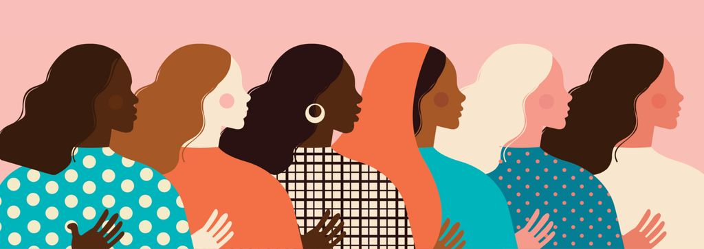

# **International Women’s Day Special Report - Women’s Legal Rights**

Author: Mengyun Yang Supervisor: James Goldie at 360info

16/12/2021

# Abstract

# Background

For the past 47 years, International Women’s Day has been celebrated worldwide on the 8th of March. It honours women’s social, economic, cultural, and political achievements. The day also serves as a rallying cry for greater gender equality. Although the past decades have been significant progress for women’s and girls’ rights. Overall, though, progress has been uneven and slow. The worldwide gender gap will not close for another 100 years at the current rate of progress (United Nations, n.d.). This analysis aims to identify the bias in the creation of laws which can disadvantage women - both socially and economically.

# Objectives

# Methodology

# Data sources

The data used in this project consists of 4 separate data set. The women, business and the law data, gender gap index data and gender indicator data were all obtained from open data source The World Bank Data’s [Women, Business and the Law Data Portal](https://wbl.worldbank.org/en/wbl-data), [Overall Global Gender Gap Index Portal](https://tcdata360.worldbank.org/indicators/af52ebe9?country=BRA&indicator=27959&viz=line_chart&years=2006,2021) and [Gender Portal](https://data.worldbank.org/topic/gender) respectively. The democracy ratings data is also an open data that sourced from [V-Dem (Varieties of Democracy by University of Gothenburg)](https://www.v-dem.net/vdemds.html).

## The women, business and the law data

The women, business and the law data set contains 10 sheets of data. It assesses the economic empowerment of women. It is based on the countries’ formal laws and regulations that have a bearing on women’s economic participation, covering eight areas such as mobility, workplace, pay, marriage, parenthood, entrepreneurship, assets and pension. It tracks how laws affect women at different stages in their working lives and focusing on those laws applicable in the main business city (Civilsdaily 2020). The first two sheets are overall WBL index scores, individual indicator scores go evaluate 35 parts of the law from 190 economies from years 1971 to 2021. The subsequent sheets present answer for the scored questions by 8 indicators. Indicator-level scores are obtained by calculating the unweighed average of the questions within that indicator and scaling the result to 100. Overall scores are then calculated by taking the average of each indicator, with 100 representing the highest possible score, a higher score suggests that there are more laws promoting gender equality (The World Bank | Women, Business and the Law, n.d.) (see Table 1 for scoring method for WBL data). There are no missing values presented in this data set.

Table 1: Scoring method for WBL data

| Score | Range |
| --- | --- |
| WBL Index | 0 - 100 |
| Indicator Score | 0 - 100 |
| Answer to Scored Question | Yes/No |
| Answer Score | 1(Yes)/0(No) |

Source: The World Bank

## The gender index data

Gender equality is critical to the success of economies and communities. Ensuring the full development and effective deployment of half of the world’s entire talent pool has a significant impact on global economic growth, competitiveness, and future-readiness. The Index is more concerned with measuring gaps than with assessing levels. Second, rather than gaps in input data, it captures gaps in outcome variables. Third, rather than focusing on women’s empowerment, it rates countries based on gender equality. Economic Participation and Opportunity, Educational Attainment, Health and Survival and Political Empowerment are the four core categories (sub-indexes) that the Global Gender Gap Index covers (The World Bank, TCdata360, n.d.). This data set contains 19 indicators under this four core categories for measuring gender gap across 157 countries from 2006 - 2021, see Table 2 for explanation of the variable used in this analysis.

Table 2: Codebook for gender gap index data

| INDICATOR | TYPE | RANGE | CLARIFICATION |
| --- | --- | --- | --- |
| Overall Global Gender Gap Index | Index | 0 - 1 | The highest possible score is 1 (equality) and the lowest possible score is 0 (inequality). |

Source: The World Bank

## The gender indicator data

Table 3: Summary of missing value of gender indicator data frame (scrollable)

| skim_type | skim_variable | n_missing | complete_rate | character.min | character.max | character.empty | character.n_unique | character.whitespace | numeric.mean | numeric.sd | numeric.p0 | numeric.p25 | numeric.p50 | numeric.p75 | numeric.p100 | numeric.hist |
| --- | --- | --- | --- | --- | --- | --- | --- | --- | --- | --- | --- | --- | --- | --- | --- | --- |
| character | Country.Name | 0 | 1.0000000 | 4 | 52 | 0 | 266 | 0 | NA | NA | NA | NA | NA | NA | NA | NA |
| character | Country.Code | 0 | 1.0000000 | 3 | 3 | 0 | 266 | 0 | NA | NA | NA | NA | NA | NA | NA | NA |
| character | Indicator.Name | 0 | 1.0000000 | 35 | 140 | 0 | 156 | 0 | NA | NA | NA | NA | NA | NA | NA | NA |
| character | Indicator.Code | 0 | 1.0000000 | 11 | 20 | 0 | 156 | 0 | NA | NA | NA | NA | NA | NA | NA | NA |
| numeric | X1960 | 39580 | 0.0461731 | NA | NA | NA | NA | NA | 118.3055 | 135.1321 | 1.94 | 38.01526 | 60.93746 | 147.50128 | 621.754 | ▇▁▁▁▁ |
| numeric | X1961 | 39578 | 0.0462213 | NA | NA | NA | NA | NA | 117.2931 | 133.1740 | 1.94 | 38.61158 | 61.57800 | 145.68535 | 620.742 | ▇▁▁▁▁ |
| numeric | X1962 | 39580 | 0.0461731 | NA | NA | NA | NA | NA | 116.7079 | 131.3738 | 1.79 | 39.00168 | 62.22900 | 147.44175 | 619.729 | ▇▁▁▁▁ |
| numeric | X1963 | 39581 | 0.0461490 | NA | NA | NA | NA | NA | 115.7917 | 129.1565 | 1.82 | 39.72550 | 62.36990 | 146.54246 | 611.160 | ▇▁▁▁▁ |
| numeric | X1964 | 39582 | 0.0461249 | NA | NA | NA | NA | NA | 114.7671 | 126.9163 | 1.79 | 40.25859 | 62.69764 | 145.45633 | 602.590 | ▇▁▁▁▁ |
| numeric | X1965 | 39577 | 0.0462454 | NA | NA | NA | NA | NA | 113.7555 | 124.6866 | 1.74 | 40.88604 | 63.30900 | 144.74218 | 594.020 | ▇▁▁▁▁ |
| numeric | X1966 | 39577 | 0.0462454 | NA | NA | NA | NA | NA | 112.8773 | 122.5784 | 1.58 | 41.49023 | 63.67400 | 142.43125 | 585.451 | ▇▁▁▁▁ |
| numeric | X1967 | 39577 | 0.0462454 | NA | NA | NA | NA | NA | 111.9349 | 120.5555 | 1.80 | 41.94229 | 63.70000 | 141.35058 | 576.881 | ▇▂▁▁▁ |
| numeric | X1968 | 39578 | 0.0462213 | NA | NA | NA | NA | NA | 111.2216 | 118.7717 | 1.83 | 42.30425 | 63.96039 | 140.25325 | 566.017 | ▇▂▁▁▁ |
| numeric | X1969 | 39575 | 0.0462936 | NA | NA | NA | NA | NA | 110.4804 | 116.9914 | 1.87 | 42.68078 | 64.28896 | 138.25100 | 563.258 | ▇▂▁▁▁ |
| numeric | X1970 | 37244 | 0.1024677 | NA | NA | NA | NA | NA | 210906.0130 | 3010345.5663 | 0.00 | 15.83735 | 48.32438 | 75.92699 | 76632976.000 | ▇▁▁▁▁ |
| numeric | X1971 | 35418 | 0.1464719 | NA | NA | NA | NA | NA | 157772.6702 | 2611497.2668 | 0.00 | 12.64835 | 46.45239 | 75.53774 | 79344496.000 | ▇▁▁▁▁ |
| numeric | X1972 | 35443 | 0.1458695 | NA | NA | NA | NA | NA | 169676.3737 | 2632422.6741 | 0.00 | 15.53594 | 48.18454 | 78.05656 | 78813968.000 | ▇▁▁▁▁ |
| numeric | X1973 | 35458 | 0.1455080 | NA | NA | NA | NA | NA | 166990.9668 | 2492645.5963 | 0.00 | 17.05982 | 48.77772 | 79.12719 | 73711688.000 | ▇▁▁▁▁ |
| numeric | X1974 | 35469 | 0.1452429 | NA | NA | NA | NA | NA | 168133.5173 | 2489731.3301 | 0.00 | 16.80292 | 49.19024 | 79.68276 | 73143912.000 | ▇▁▁▁▁ |
| numeric | X1975 | 35369 | 0.1476528 | NA | NA | NA | NA | NA | 176381.3672 | 2450164.8889 | 0.00 | 17.50278 | 49.84162 | 80.33064 | 70673896.000 | ▇▁▁▁▁ |
| numeric | X1976 | 35111 | 0.1538703 | NA | NA | NA | NA | NA | 167657.7421 | 2391716.9671 | 0.00 | 18.03485 | 50.49503 | 80.91628 | 70429336.000 | ▇▁▁▁▁ |
| numeric | X1977 | 35165 | 0.1525689 | NA | NA | NA | NA | NA | 169238.6863 | 2438436.7965 | 0.00 | 19.42799 | 51.62061 | 82.29653 | 72978544.000 | ▇▁▁▁▁ |
| numeric | X1978 | 35101 | 0.1541112 | NA | NA | NA | NA | NA | 175800.8855 | 2584424.3999 | 0.00 | 20.81463 | 52.15033 | 83.39713 | 78935424.000 | ▇▁▁▁▁ |
| numeric | X1979 | 35123 | 0.1535811 | NA | NA | NA | NA | NA | 174439.3954 | 2593811.5101 | 0.00 | 21.03960 | 52.38960 | 83.26570 | 79433040.000 | ▇▁▁▁▁ |
| numeric | X1980 | 34899 | 0.1589792 | NA | NA | NA | NA | NA | 163190.0566 | 2483596.7990 | 0.00 | 18.84574 | 52.15533 | 83.50715 | 76823904.000 | ▇▁▁▁▁ |
| numeric | X1981 | 34715 | 0.1634133 | NA | NA | NA | NA | NA | 156601.8725 | 2379570.5826 | 0.00 | 20.65334 | 52.67347 | 85.33006 | 74454816.000 | ▇▁▁▁▁ |
| numeric | X1982 | 34970 | 0.1572682 | NA | NA | NA | NA | NA | 160950.8510 | 2399059.8450 | 0.00 | 23.75621 | 54.17753 | 86.25669 | 73524176.000 | ▇▁▁▁▁ |
| numeric | X1983 | 34867 | 0.1597503 | NA | NA | NA | NA | NA | 158799.8869 | 2359623.1873 | 0.00 | 24.55228 | 54.73525 | 87.39115 | 72946512.000 | ▇▁▁▁▁ |
| numeric | X1984 | 34790 | 0.1616059 | NA | NA | NA | NA | NA | 160766.1314 | 2338058.4820 | 0.00 | 24.43175 | 54.89133 | 87.18956 | 71831712.000 | ▇▁▁▁▁ |
| numeric | X1985 | 34780 | 0.1618469 | NA | NA | NA | NA | NA | 159669.8129 | 2285457.1147 | 0.00 | 24.88961 | 54.97360 | 86.77310 | 68952408.000 | ▇▁▁▁▁ |
| numeric | X1986 | 34499 | 0.1686187 | NA | NA | NA | NA | NA | 161344.3760 | 2197723.2766 | 0.00 | 25.12086 | 54.91027 | 85.84491 | 65505904.000 | ▇▁▁▁▁ |
| numeric | X1987 | 34688 | 0.1640640 | NA | NA | NA | NA | NA | 166110.3161 | 2232032.3274 | 0.00 | 25.77901 | 55.94097 | 86.01028 | 64398156.000 | ▇▁▁▁▁ |
| numeric | X1988 | 34732 | 0.1630037 | NA | NA | NA | NA | NA | 162695.4803 | 2188205.2658 | 0.00 | 26.63836 | 56.26900 | 85.98508 | 62572648.000 | ▇▁▁▁▁ |
| numeric | X1989 | 34727 | 0.1631242 | NA | NA | NA | NA | NA | 160189.9114 | 2140041.1713 | 0.00 | 26.25000 | 57.13392 | 88.06554 | 60735836.000 | ▇▁▁▁▁ |
| numeric | X1990 | 33389 | 0.1953682 | NA | NA | NA | NA | NA | 137822.8669 | 2004432.4530 | 0.00 | 21.99823 | 53.12500 | 82.13406 | 61349664.000 | ▇▁▁▁▁ |
| numeric | X1991 | 27476 | 0.3378639 | NA | NA | NA | NA | NA | 78540.9709 | 1523293.3467 | 0.00 | 11.39750 | 44.26724 | 72.78886 | 61462952.000 | ▇▁▁▁▁ |
| numeric | X1992 | 27522 | 0.3367553 | NA | NA | NA | NA | NA | 81466.0544 | 1566467.5396 | 0.00 | 11.58250 | 44.36643 | 73.19650 | 63139752.000 | ▇▁▁▁▁ |
| numeric | X1993 | 27574 | 0.3355022 | NA | NA | NA | NA | NA | 83141.3214 | 1577082.6174 | 0.00 | 11.82050 | 44.83500 | 73.73761 | 63199364.000 | ▇▁▁▁▁ |
| numeric | X1994 | 27491 | 0.3375024 | NA | NA | NA | NA | NA | 84499.3090 | 1584986.9921 | 0.00 | 12.21000 | 45.24888 | 74.26643 | 63467880.000 | ▇▁▁▁▁ |
| numeric | X1995 | 27504 | 0.3371891 | NA | NA | NA | NA | NA | 87687.1494 | 1637902.9697 | 0.00 | 12.23450 | 45.45523 | 74.69550 | 65651860.000 | ▇▁▁▁▁ |
| numeric | X1996 | 27563 | 0.3357673 | NA | NA | NA | NA | NA | 90490.4784 | 1686263.9961 | 0.00 | 12.09000 | 45.40000 | 74.66000 | 66859652.000 | ▇▁▁▁▁ |
| numeric | X1997 | 27870 | 0.3283690 | NA | NA | NA | NA | NA | 92891.3115 | 1709499.6907 | 0.00 | 11.45000 | 44.61991 | 73.67675 | 66889084.000 | ▇▁▁▁▁ |
| numeric | X1998 | 27197 | 0.3445874 | NA | NA | NA | NA | NA | 86635.9576 | 1632917.8618 | 0.00 | 12.11738 | 45.48013 | 74.80000 | 64300864.000 | ▇▁▁▁▁ |
| numeric | X1999 | 25267 | 0.3910979 | NA | NA | NA | NA | NA | 73930.5596 | 1462275.8299 | 0.00 | 13.06848 | 47.14509 | 77.53177 | 60054672.000 | ▇▁▁▁▁ |
| numeric | X2000 | 23290 | 0.4387411 | NA | NA | NA | NA | NA | 63251.8268 | 1311676.7225 | 0.00 | 12.96256 | 46.99553 | 78.39650 | 56769112.000 | ▇▁▁▁▁ |
| numeric | X2001 | 24204 | 0.4167149 | NA | NA | NA | NA | NA | 63612.1100 | 1296574.0079 | 0.00 | 12.48758 | 47.53566 | 79.08618 | 54486580.000 | ▇▁▁▁▁ |
| numeric | X2002 | 24333 | 0.4136061 | NA | NA | NA | NA | NA | 61689.1288 | 1251819.9488 | 0.00 | 12.35200 | 47.86431 | 79.69579 | 52181804.000 | ▇▁▁▁▁ |
| numeric | X2003 | 24411 | 0.4117264 | NA | NA | NA | NA | NA | 56061.8987 | 1122656.0173 | 0.00 | 12.55200 | 47.79374 | 79.94482 | 44700024.000 | ▇▁▁▁▁ |
| numeric | X2004 | 23849 | 0.4252699 | NA | NA | NA | NA | NA | 50384.1037 | 1027869.2599 | 0.00 | 13.00000 | 48.24324 | 80.76076 | 41665004.000 | ▇▁▁▁▁ |
| numeric | X2005 | 22992 | 0.4459225 | NA | NA | NA | NA | NA | 45089.3143 | 940619.5941 | 0.00 | 12.80354 | 47.60478 | 80.22900 | 38787744.000 | ▇▁▁▁▁ |
| numeric | X2006 | 23206 | 0.4407654 | NA | NA | NA | NA | NA | 44378.1675 | 916721.3880 | 0.00 | 12.46425 | 47.72233 | 80.43971 | 37375428.000 | ▇▁▁▁▁ |
| numeric | X2007 | 23116 | 0.4429343 | NA | NA | NA | NA | NA | 39467.0859 | 816655.5239 | 0.00 | 13.04843 | 48.59533 | 82.01250 | 33428720.000 | ▇▁▁▁▁ |
| numeric | X2008 | 23007 | 0.4455610 | NA | NA | NA | NA | NA | 38591.9928 | 800604.9857 | 0.00 | 13.22000 | 48.64487 | 82.12354 | 31976256.000 | ▇▁▁▁▁ |
| numeric | X2009 | 22795 | 0.4506699 | NA | NA | NA | NA | NA | 38762.3035 | 806166.2226 | 0.00 | 13.59000 | 48.56768 | 82.31398 | 31757624.000 | ▇▁▁▁▁ |
| numeric | X2010 | 21886 | 0.4725757 | NA | NA | NA | NA | NA | 36835.0114 | 789322.7914 | 0.00 | 13.36075 | 47.90050 | 81.73515 | 31417024.000 | ▇▁▁▁▁ |
| numeric | X2011 | 22312 | 0.4623096 | NA | NA | NA | NA | NA | 37293.7577 | 793518.2835 | 0.00 | 13.02036 | 48.56695 | 82.91285 | 30969422.000 | ▇▁▁▁▁ |
| numeric | X2012 | 22247 | 0.4638760 | NA | NA | NA | NA | NA | 36329.6033 | 776001.8013 | 0.00 | 12.72000 | 48.42260 | 82.43651 | 30693964.000 | ▇▁▁▁▁ |
| numeric | X2013 | 22595 | 0.4554897 | NA | NA | NA | NA | NA | 36144.2183 | 767581.6832 | 0.00 | 13.01700 | 48.55000 | 82.38241 | 30265960.000 | ▇▁▁▁▁ |
| numeric | X2014 | 22014 | 0.4694910 | NA | NA | NA | NA | NA | 36706.6838 | 794968.3039 | 0.00 | 12.69184 | 48.57586 | 83.10568 | 32261116.000 | ▇▁▁▁▁ |
| numeric | X2015 | 21869 | 0.4729853 | NA | NA | NA | NA | NA | 37635.4395 | 824217.0040 | 0.00 | 12.58800 | 48.14172 | 82.42249 | 33491012.000 | ▇▁▁▁▁ |
| numeric | X2016 | 22420 | 0.4597070 | NA | NA | NA | NA | NA | 38390.5691 | 828500.5998 | 0.00 | 12.94000 | 48.79867 | 83.75000 | 33278072.000 | ▇▁▁▁▁ |
| numeric | X2017 | 23127 | 0.4426692 | NA | NA | NA | NA | NA | 40153.7558 | 852148.7679 | 0.00 | 12.39669 | 48.83501 | 83.57071 | 33507876.000 | ▇▁▁▁▁ |
| numeric | X2018 | 24242 | 0.4157991 | NA | NA | NA | NA | NA | 41815.4521 | 864075.9177 | 0.00 | 11.92860 | 46.97661 | 80.27000 | 33476776.000 | ▇▁▁▁▁ |
| numeric | X2019 | 26795 | 0.3542751 | NA | NA | NA | NA | NA | 49469.8284 | 954430.8943 | 0.00 | 10.43154 | 42.19153 | 76.54593 | 33792500.000 | ▇▁▁▁▁ |
| numeric | X2020 | 32758 | 0.2105745 | NA | NA | NA | NA | NA | 1780.7498 | 56644.1585 | 0.00 | 14.48670 | 44.77114 | 75.50715 | 4108190.000 | ▇▁▁▁▁ |
| numeric | X2021 | 39330 | 0.0521978 | NA | NA | NA | NA | NA | 150.6775 | 3152.4076 | 0.00 | 17.10357 | 45.20084 | 64.37725 | 118386.000 | ▇▁▁▁▁ |

Table 4: Codebook of gender indicator (scrollable)

INDICATOR_CODE

INDICATOR_NAME

SOURCE_NOTE

SOURCE_ORGANIZATION

SP.MTR.1519.ZS

Teenage mothers (% of women ages 15-19 who have had children or are currently pregnant)

Teenage mothers are the percentage of women ages 15-19 who already have children or are currently pregnant.

Demographic and Health Surveys.

SP.M18.2024.FE.ZS

Women who were first married by age 18 (% of women ages 20-24)

Women who were first married by age 18 refers to the percentage of women ages 20-24 who were first married by age 18.

UNICEF Data; Demographic and Health Surveys (DHS), Multiple Indicator Cluster Surveys (MICS), AIDS Indicator Surveys(AIS), Reproductive Health Survey(RHS), and other household surveys.

SP.M15.2024.FE.ZS

Women who were first married by age 15 (% of women ages 20-24)

Women who were first married by age 15 refers to the percentage of women ages 20-24 who were first married by age 15.

UNICEF Data; Demographic and Health Surveys (DHS), Multiple Indicator Cluster Surveys (MICS), AIDS Indicator Surveys(AIS), Reproductive Health Survey(RHS), and other household surveys.

SP.HOU.FEMA.ZS

Female headed households (% of households with a female head)

Female headed households shows the percentage of households with a female head.

Demographic and Health Surveys.

SP.DYN.WFRT

Wanted fertility rate (births per woman)

Wanted fertility rate is an estimate of what the total fertility rate would be if all unwanted births were avoided.

Demographic and Health Surveys.

SP.DYN.TO65.MA.ZS

Survival to age 65, male (% of cohort)

Survival to age 65 refers to the percentage of a cohort of newborn infants that would survive to age 65, if subject to age specific mortality rates of the specified year.

United Nations Population Division. World Population Prospects: 2019 Revision.

SP.DYN.TO65.FE.ZS

Survival to age 65, female (% of cohort)

Survival to age 65 refers to the percentage of a cohort of newborn infants that would survive to age 65, if subject to age specific mortality rates of the specified year.

United Nations Population Division. World Population Prospects: 2019 Revision.

SP.DYN.TFRT.IN

Fertility rate, total (births per woman)

Total fertility rate represents the number of children that would be born to a woman if she were to live to the end of her childbearing years and bear children in accordance with age-specific fertility rates of the specified year.

1. United Nations Population Division. World Population Prospects: 2019 Revision. (2) Census reports and other statistical publications from national statistical offices, (3) Eurostat: Demographic Statistics, (4) United Nations Statistical Division. Population and Vital Statistics Reprot (various years), (5) U.S. Census Bureau: International Database, and (6) Secretariat of the Pacific Community: Statistics and Demography Programme.

SP.DYN.LE00.MA.IN

Life expectancy at birth, male (years)

Life expectancy at birth indicates the number of years a newborn infant would live if prevailing patterns of mortality at the time of its birth were to stay the same throughout its life.

1. United Nations Population Division. World Population Prospects: 2019 Revision. (2) Census reports and other statistical publications from national statistical offices, (3) Eurostat: Demographic Statistics, (4) United Nations Statistical Division. Population and Vital Statistics Reprot (various years), (5) U.S. Census Bureau: International Database, and (6) Secretariat of the Pacific Community: Statistics and Demography Programme.

SP.DYN.LE00.FE.IN

Life expectancy at birth, female (years)

Life expectancy at birth indicates the number of years a newborn infant would live if prevailing patterns of mortality at the time of its birth were to stay the same throughout its life.

1. United Nations Population Division. World Population Prospects: 2019 Revision. (2) Census reports and other statistical publications from national statistical offices, (3) Eurostat: Demographic Statistics, (4) United Nations Statistical Division. Population and Vital Statistics Reprot (various years), (5) U.S. Census Bureau: International Database, and (6) Secretariat of the Pacific Community: Statistics and Demography Programme.

SP.DYN.CONU.ZS

Contraceptive prevalence, any method (% of married women ages 15-49)

Contraceptive prevalence, any method is the percentage of married women ages 15-49 who are practicing, or whose sexual partners are practicing, any method of contraception (modern or traditional). Modern methods of contraception include female and male sterilization, oral hormonal pills, the intra-uterine device (IUD), the male condom, injectables, the implant (including Norplant), vaginal barrier methods, the female condom and emergency contraception. Traditional methods of contraception include rhythm (e.g., fertility awareness based methods, periodic abstinence), withdrawal and other traditional methods.

Household surveys, including Demographic and Health Surveys and Multiple Indicator Cluster Surveys. Largely compiled by United Nations Population Division.

SP.DYN.AMRT.MA

Mortality rate, adult, male (per 1,000 male adults)

Adult mortality rate, male, is the probability of dying between the ages of 15 and 60–that is, the probability of a 15-year-old male dying before reaching age 60, if subject to age-specific mortality rates of the specified year between those ages.

1. United Nations Population Division. World Population Prospects: 2019 Revision. (2) University of California, Berkeley, and Max Planck Institute for Demographic Research. The Human Mortality Database.

SP.DYN.AMRT.FE

Mortality rate, adult, female (per 1,000 female adults)

Adult mortality rate, female, is the probability of dying between the ages of 15 and 60–that is, the probability of a 15-year-old female dying before reaching age 60, if subject to age-specific mortality rates of the specified year between those ages.

1. United Nations Population Division. World Population Prospects: 2019 Revision. (2) University of California, Berkeley, and Max Planck Institute for Demographic Research. The Human Mortality Database.

SP.ADO.TFRT

Adolescent fertility rate (births per 1,000 women ages 15-19)

Adolescent fertility rate is the number of births per 1,000 women ages 15-19.

United Nations Population Division, World Population Prospects.

SL.UEM.TOTL.MA.ZS

Unemployment, male (% of male labor force) (modeled ILO estimate)

Unemployment refers to the share of the labor force that is without work but available for and seeking employment.

International Labour Organization, ILOSTAT database. Data retrieved on February 8, 2022.

SL.UEM.TOTL.FE.ZS

Unemployment, female (% of female labor force) (modeled ILO estimate)

Unemployment refers to the share of the labor force that is without work but available for and seeking employment.

International Labour Organization, ILOSTAT database. Data retrieved on February 8, 2022.

SL.UEM.1524.MA.ZS

Unemployment, youth male (% of male labor force ages 15-24) (modeled ILO estimate)

Youth unemployment refers to the share of the labor force ages 15-24 without work but available for and seeking employment.

International Labour Organization, ILOSTAT database. Data retrieved on February 8, 2022.

SL.UEM.1524.FE.ZS

Unemployment, youth female (% of female labor force ages 15-24) (modeled ILO estimate)

Youth unemployment refers to the share of the labor force ages 15-24 without work but available for and seeking employment.

International Labour Organization, ILOSTAT database. Data retrieved on February 8, 2022.

SL.TLF.TOTL.FE.ZS

Labor force, female (% of total labor force)

Female labor force as a percentage of the total show the extent to which women are active in the labor force. Labor force comprises people ages 15 and older who supply labor for the production of goods and services during a specified period.

Derived using data from International Labour Organization, ILOSTAT database. The data was retrieved on February 8, 2022.

SL.TLF.PART.MA.ZS

Part time employment, male (% of total male employment)

Part time employment refers to regular employment in which working time is substantially less than normal. Definitions of part time employment differ by country.

International Labour Organization, ILOSTAT database. Data retrieved on February 8, 2022.

SL.TLF.PART.FE.ZS

Part time employment, female (% of total female employment)

Part time employment refers to regular employment in which working time is substantially less than normal. Definitions of part time employment differ by country.

International Labour Organization, ILOSTAT database. Data retrieved on February 8, 2022.

SL.TLF.CACT.MA.ZS

Labor force participation rate, male (% of male population ages 15+) (modeled ILO estimate)

Labor force participation rate is the proportion of the population ages 15 and older that is economically active: all people who supply labor for the production of goods and services during a specified period.

International Labour Organization, ILOSTAT database. Data retrieved on February 8, 2022.

SL.TLF.CACT.FE.ZS

Labor force participation rate, female (% of female population ages 15+) (modeled ILO estimate)

Labor force participation rate is the proportion of the population ages 15 and older that is economically active: all people who supply labor for the production of goods and services during a specified period.

International Labour Organization, ILOSTAT database. Data retrieved on February 8, 2022.

SL.TLF.0714.WK.MA.ZS

Children in employment, work only, male (% of male children in employment, ages 7-14)

Children in employment refer to children involved in economic activity for at least one hour in the reference week of the survey. Work only refers to children involved in economic activity and not attending school.

Understanding Children’s Work project based on data from ILO, UNICEF and the World Bank.

SL.TLF.0714.WK.FE.ZS

Children in employment, work only, female (% of female children in employment, ages 7-14)

Children in employment refer to children involved in economic activity for at least one hour in the reference week of the survey. Work only refers to children involved in economic activity and not attending school.

Understanding Children’s Work project based on data from ILO, UNICEF and the World Bank.

SL.TLF.0714.SW.MA.ZS

Children in employment, study and work, male (% of male children in employment, ages 7-14)

Children in employment refer to children involved in economic activity for at least one hour in the reference week of the survey. Study and work refer to children attending school in combination with economic activity.

Understanding Children’s Work project based on data from ILO, UNICEF and the World Bank.

SL.TLF.0714.SW.FE.ZS

Children in employment, study and work, female (% of female children in employment, ages 7-14)

Children in employment refer to children involved in economic activity for at least one hour in the reference week of the survey. Study and work refer to children attending school in combination with economic activity.

Understanding Children’s Work project based on data from ILO, UNICEF and the World Bank.

SL.TLF.0714.MA.ZS

Children in employment, male (% of male children ages 7-14)

Children in employment refer to children involved in economic activity for at least one hour in the reference week of the survey.

Understanding Children’s Work project based on data from ILO, UNICEF and the World Bank.

SL.TLF.0714.FE.ZS

Children in employment, female (% of female children ages 7-14)

Children in employment refer to children involved in economic activity for at least one hour in the reference week of the survey.

Understanding Children’s Work project based on data from ILO, UNICEF and the World Bank.

SL.SRV.EMPL.MA.ZS

Employment in services, male (% of male employment) (modeled ILO estimate)

Employment is defined as persons of working age who were engaged in any activity to produce goods or provide services for pay or profit, whether at work during the reference period or not at work due to temporary absence from a job, or to working-time arrangement. The services sector consists of wholesale and retail trade and restaurants and hotels; transport, storage, and communications; financing, insurance, real estate, and business services; and community, social, and personal services, in accordance with divisions 6-9 (ISIC 2) or categories G-Q (ISIC 3) or categories G-U (ISIC 4).

International Labour Organization, ILOSTAT database. Data retrieved on January 29, 2021.

SL.SRV.EMPL.FE.ZS

Employment in services, female (% of female employment) (modeled ILO estimate)

Employment is defined as persons of working age who were engaged in any activity to produce goods or provide services for pay or profit, whether at work during the reference period or not at work due to temporary absence from a job, or to working-time arrangement. The services sector consists of wholesale and retail trade and restaurants and hotels; transport, storage, and communications; financing, insurance, real estate, and business services; and community, social, and personal services, in accordance with divisions 6-9 (ISIC 2) or categories G-Q (ISIC 3) or categories G-U (ISIC 4).

International Labour Organization, ILOSTAT database. Data retrieved on January 29, 2021.

SL.SRV.0714.MA.ZS

Child employment in services, male (% of male economically active children ages 7-14)

Employment by economic activity refers to the distribution of economically active children by the major industrial categories of the International Standard Industrial Classification (ISIC). Services correspond to divisions 6-9 (ISIC revision 2), categories G-P (ISIC revision 3), or categories G-U (ISIC revision 4). Services include wholesale and retail trade, hotels and restaurants, transport, financial intermediation, real estate, public administration, education, health and social work, other community services, and private household activity. Economically active children refer to children involved in economic activity for at least one hour in the reference week of the survey.

Understanding Children’s Work project based on data from ILO, UNICEF and the World Bank.

SL.SRV.0714.FE.ZS

Child employment in services, female (% of female economically active children ages 7-14)

Employment by economic activity refers to the distribution of economically active children by the major industrial categories of the International Standard Industrial Classification (ISIC). Services correspond to divisions 6-9 (ISIC revision 2), categories G-P (ISIC revision 3), or categories G-U (ISIC revision 4). Services include wholesale and retail trade, hotels and restaurants, transport, financial intermediation, real estate, public administration, education, health and social work, other community services, and private household activity. Economically active children refer to children involved in economic activity for at least one hour in the reference week of the survey.

Understanding Children’s Work project based on data from ILO, UNICEF and the World Bank.

SL.MNF.0714.MA.ZS

Child employment in manufacturing, male (% of male economically active children ages 7-14)

Employment by economic activity refers to the distribution of economically active children by the major industrial categories of the International Standard Industrial Classification (ISIC). Manufacturing corresponds to division 3 (ISIC revision 2), category D (ISIC revision 3), or category C (ISIC revision 4). Economically active children refer to children involved in economic activity for at least one hour in the reference week of the survey.

Understanding Children’s Work project based on data from ILO, UNICEF and the World Bank.

SL.MNF.0714.FE.ZS

Child employment in manufacturing, female (% of female economically active children ages 7-14)

Employment by economic activity refers to the distribution of economically active children by the major industrial categories of the International Standard Industrial Classification (ISIC). Manufacturing corresponds to division 3 (ISIC revision 2), category D (ISIC revision 3), or category C (ISIC revision 4). Economically active children refer to children involved in economic activity for at least one hour in the reference week of the survey.

Understanding Children’s Work project based on data from ILO, UNICEF and the World Bank.

SL.IND.EMPL.MA.ZS

Employment in industry, male (% of male employment) (modeled ILO estimate)

Employment is defined as persons of working age who were engaged in any activity to produce goods or provide services for pay or profit, whether at work during the reference period or not at work due to temporary absence from a job, or to working-time arrangement. The industry sector consists of mining and quarrying, manufacturing, construction, and public utilities (electricity, gas, and water), in accordance with divisions 2-5 (ISIC 2) or categories C-F (ISIC 3) or categories B-F (ISIC 4).

International Labour Organization, ILOSTAT database. Data retrieved on January 29, 2021.

SL.IND.EMPL.FE.ZS

Employment in industry, female (% of female employment) (modeled ILO estimate)

Employment is defined as persons of working age who were engaged in any activity to produce goods or provide services for pay or profit, whether at work during the reference period or not at work due to temporary absence from a job, or to working-time arrangement. The industry sector consists of mining and quarrying, manufacturing, construction, and public utilities (electricity, gas, and water), in accordance with divisions 2-5 (ISIC 2) or categories C-F (ISIC 3) or categories B-F (ISIC 4).

International Labour Organization, ILOSTAT database. Data retrieved on January 29, 2021.

SL.FAM.WORK.MA.ZS

Contributing family workers, male (% of male employment) (modeled ILO estimate)

Contributing family workers are those workers who hold “self-employment jobs” as own-account workers in a market-oriented establishment operated by a related person living in the same household.

International Labour Organization, ILOSTAT database. Data retrieved on January 29, 2021.

SL.FAM.WORK.FE.ZS

Contributing family workers, female (% of female employment) (modeled ILO estimate)

Contributing family workers are those workers who hold “self-employment jobs” as own-account workers in a market-oriented establishment operated by a related person living in the same household.

International Labour Organization, ILOSTAT database. Data retrieved on January 29, 2021.

SL.EMP.WORK.MA.ZS

Wage and salaried workers, male (% of male employment) (modeled ILO estimate)

Wage and salaried workers (employees) are those workers who hold the type of jobs defined as “paid employment jobs,” where the incumbents hold explicit (written or oral) or implicit employment contracts that give them a basic remuneration that is not directly dependent upon the revenue of the unit for which they work.

International Labour Organization, ILOSTAT database. Data retrieved on January 29, 2021.

SL.EMP.WORK.FE.ZS

Wage and salaried workers, female (% of female employment) (modeled ILO estimate)

Wage and salaried workers (employees) are those workers who hold the type of jobs defined as “paid employment jobs,” where the incumbents hold explicit (written or oral) or implicit employment contracts that give them a basic remuneration that is not directly dependent upon the revenue of the unit for which they work.

International Labour Organization, ILOSTAT database. Data retrieved on January 29, 2021.

SL.EMP.VULN.MA.ZS

Vulnerable employment, male (% of male employment) (modeled ILO estimate)

Vulnerable employment is contributing family workers and own-account workers as a percentage of total employment.

Derived using data from International Labour Organization, ILOSTAT database. The data retrieved on January 29, 2021.

SL.EMP.VULN.FE.ZS

Vulnerable employment, female (% of female employment) (modeled ILO estimate)

Vulnerable employment is contributing family workers and own-account workers as a percentage of total employment.

Derived using data from International Labour Organization, ILOSTAT database. The data retrieved on January 29, 2021.

SL.EMP.TOTL.SP.MA.ZS

Employment to population ratio, 15+, male (%) (modeled ILO estimate)

Employment to population ratio is the proportion of a country’s population that is employed. Employment is defined as persons of working age who, during a short reference period, were engaged in any activity to produce goods or provide services for pay or profit, whether at work during the reference period (i.e. who worked in a job for at least one hour) or not at work due to temporary absence from a job, or to working-time arrangements. Ages 15 and older are generally considered the working-age population.

International Labour Organization, ILOSTAT database. Data retrieved on February 8, 2022.

SL.EMP.TOTL.SP.FE.ZS

Employment to population ratio, 15+, female (%) (modeled ILO estimate)

Employment to population ratio is the proportion of a country’s population that is employed. Employment is defined as persons of working age who, during a short reference period, were engaged in any activity to produce goods or provide services for pay or profit, whether at work during the reference period (i.e. who worked in a job for at least one hour) or not at work due to temporary absence from a job, or to working-time arrangements. Ages 15 and older are generally considered the working-age population.

International Labour Organization, ILOSTAT database. Data retrieved on February 8, 2022.

SL.EMP.SELF.MA.ZS

Self-employed, male (% of male employment) (modeled ILO estimate)

Self-employed workers are those workers who, working on their own account or with one or a few partners or in cooperative, hold the type of jobs defined as a “self-employment jobs.” i.e. jobs where the remuneration is directly dependent upon the profits derived from the goods and services produced. Self-employed workers include four sub-categories of employers, own-account workers, members of producers’ cooperatives, and contributing family workers.

International Labour Organization, ILOSTAT database. Data retrieved on January 29, 2021.

SL.EMP.SELF.FE.ZS

Self-employed, female (% of female employment) (modeled ILO estimate)

Self-employed workers are those workers who, working on their own account or with one or a few partners or in cooperative, hold the type of jobs defined as a “self-employment jobs.” i.e. jobs where the remuneration is directly dependent upon the profits derived from the goods and services produced. Self-employed workers include four sub-categories of employers, own-account workers, members of producers’ cooperatives, and contributing family workers.

International Labour Organization, ILOSTAT database. Data retrieved on January 29, 2021.

SL.EMP.MPYR.MA.ZS

Employers, male (% of male employment) (modeled ILO estimate)

Employers are those workers who, working on their own account or with one or a few partners, hold the type of jobs defined as a “self-employment jobs” i.e. jobs where the remuneration is directly dependent upon the profits derived from the goods and services produced), and, in this capacity, have engaged, on a continuous basis, one or more persons to work for them as employee(s).

International Labour Organization, ILOSTAT database. Data retrieved on January 29, 2021.

SL.EMP.MPYR.FE.ZS

Employers, female (% of female employment) (modeled ILO estimate)

Employers are those workers who, working on their own account or with one or a few partners, hold the type of jobs defined as a “self-employment jobs” i.e. jobs where the remuneration is directly dependent upon the profits derived from the goods and services produced), and, in this capacity, have engaged, on a continuous basis, one or more persons to work for them as employee(s).

International Labour Organization, ILOSTAT database. Data retrieved on January 29, 2021.

SL.EMP.1524.SP.MA.ZS

Employment to population ratio, ages 15-24, male (%) (modeled ILO estimate)

Employment to population ratio is the proportion of a country’s population that is employed. Employment is defined as persons of working age who, during a short reference period, were engaged in any activity to produce goods or provide services for pay or profit, whether at work during the reference period (i.e. who worked in a job for at least one hour) or not at work due to temporary absence from a job, or to working-time arrangements. Ages 15-24 are generally considered the youth population.

International Labour Organization, ILOSTAT database. Data retrieved on February 8, 2022.

SL.EMP.1524.SP.FE.ZS

Employment to population ratio, ages 15-24, female (%) (modeled ILO estimate)

Employment to population ratio is the proportion of a country’s population that is employed. Employment is defined as persons of working age who, during a short reference period, were engaged in any activity to produce goods or provide services for pay or profit, whether at work during the reference period (i.e. who worked in a job for at least one hour) or not at work due to temporary absence from a job, or to working-time arrangements. Ages 15-24 are generally considered the youth population.

International Labour Organization, ILOSTAT database. Data retrieved on February 8, 2022.

SL.AGR.EMPL.MA.ZS

Employment in agriculture, male (% of male employment) (modeled ILO estimate)

Employment is defined as persons of working age who were engaged in any activity to produce goods or provide services for pay or profit, whether at work during the reference period or not at work due to temporary absence from a job, or to working-time arrangement. The agriculture sector consists of activities in agriculture, hunting, forestry and fishing, in accordance with division 1 (ISIC 2) or categories A-B (ISIC 3) or category A (ISIC 4).

International Labour Organization, ILOSTAT database. Data retrieved on January 29, 2021.

SL.AGR.EMPL.FE.ZS

Employment in agriculture, female (% of female employment) (modeled ILO estimate)

Employment is defined as persons of working age who were engaged in any activity to produce goods or provide services for pay or profit, whether at work during the reference period or not at work due to temporary absence from a job, or to working-time arrangement. The agriculture sector consists of activities in agriculture, hunting, forestry and fishing, in accordance with division 1 (ISIC 2) or categories A-B (ISIC 3) or category A (ISIC 4).

International Labour Organization, ILOSTAT database. Data retrieved on January 29, 2021.

SL.AGR.0714.MA.ZS

Child employment in agriculture, male (% of male economically active children ages 7-14)

Employment by economic activity refers to the distribution of economically active children by the major industrial categories of the International Standard Industrial Classification (ISIC). Agriculture corresponds to division 1 (ISIC revision 2), categories A and B (ISIC revision 3), or category A (ISIC revision 4) and includes hunting, forestry, and fishing. Economically active children refer to children involved in economic activity for at least one hour in the reference week of the survey.

Understanding Children’s Work project based on data from ILO, UNICEF and the World Bank.

SL.AGR.0714.FE.ZS

Child employment in agriculture, female (% of female economically active children ages 7-14)

Employment by economic activity refers to the distribution of economically active children by the major industrial categories of the International Standard Industrial Classification (ISIC). Agriculture corresponds to division 1 (ISIC revision 2), categories A and B (ISIC revision 3), or category A (ISIC revision 4) and includes hunting, forestry, and fishing. Economically active children refer to children involved in economic activity for at least one hour in the reference week of the survey.

Understanding Children’s Work project based on data from ILO, UNICEF and the World Bank.

SH.STA.MMRT.NE

Maternal mortality ratio (national estimate, per 100,000 live births)

Maternal mortality ratio is the number of women who die from pregnancy-related causes while pregnant or within 42 days of pregnancy termination per 100,000 live births.

The country data compiled, adjusted and used in the estimation model by the Maternal Mortality Estimation Inter-Agency Group (MMEIG). The country data were compiled from the following sources: civil registration and vital statistics; specialized studies on maternal mortality; population based surveys and censuses; other available data sources including data from surveillance sites.

SH.STA.MMRT

Maternal mortality ratio (modeled estimate, per 100,000 live births)

Maternal mortality ratio is the number of women who die from pregnancy-related causes while pregnant or within 42 days of pregnancy termination per 100,000 live births. The data are estimated with a regression model using information on the proportion of maternal deaths among non-AIDS deaths in women ages 15-49, fertility, birth attendants, and GDP measured using purchasing power parities (PPPs).

WHO, UNICEF, UNFPA, World Bank Group, and the United Nations Population Division. Trends in Maternal Mortality: 2000 to 2017. Geneva, World Health Organization, 2019

SH.STA.MALN.MA.ZS

Prevalence of underweight, weight for age, male (% of children under 5)

Prevalence of underweight, male, is the percentage of boys under age 5 whose weight for age is more than two standard deviations below the median for the international reference population ages 0-59 months. The data are based on the WHO’s new child growth standards released in 2006.

UNICEF, WHO, World Bank: Joint child malnutrition estimates (JME). Aggregation is based on UNICEF, WHO, and the World Bank harmonized dataset (adjusted, comparable data) and methodology.

SH.STA.MALN.FE.ZS

Prevalence of underweight, weight for age, female (% of children under 5)

Prevalence of underweight, female, is the percentage of girls under age 5 whose weight for age is more than two standard deviations below the median for the international reference population ages 0-59 months. The data are based on the WHO’s new child growth standards released in 2006.

UNICEF, WHO, World Bank: Joint child malnutrition estimates (JME). Aggregation is based on UNICEF, WHO, and the World Bank harmonized dataset (adjusted, comparable data) and methodology.

SH.STA.BRTC.ZS

Births attended by skilled health staff (% of total)

Births attended by skilled health staff are the percentage of deliveries attended by personnel trained to give the necessary supervision, care, and advice to women during pregnancy, labor, and the postpartum period; to conduct deliveries on their own; and to care for newborns.

UNICEF, State of the World’s Children, Childinfo, and Demographic and Health Surveys.

SH.STA.ANVC.ZS

Pregnant women receiving prenatal care (%)

Pregnant women receiving prenatal care are the percentage of women attended at least once during pregnancy by skilled health personnel for reasons related to pregnancy.

UNICEF, State of the World’s Children, Childinfo, and Demographic and Health Surveys.

SH.PRV.SMOK.MA

Prevalence of current tobacco use, males (% of male adults)

The percentage of the male population ages 15 years and over who currently use any tobacco product (smoked and/or smokeless tobacco) on a daily or non-daily basis. Tobacco products include cigarettes, pipes, cigars, cigarillos, waterpipes (hookah, shisha), bidis, kretek, heated tobacco products, and all forms of smokeless (oral and nasal) tobacco. Tobacco products exclude e-cigarettes (which do not contain tobacco), “e-cigars”, “e-hookahs”, JUUL and “e-pipes”. The rates are age-standardized to the WHO Standard Population.

World Health Organization, Global Health Observatory Data Repository (http://apps.who.int/ghodata/).

SH.PRV.SMOK.FE

Prevalence of current tobacco use, females (% of female adults)

The percentage of the female population ages 15 years and over who currently use any tobacco product (smoked and/or smokeless tobacco) on a daily or non-daily basis. Tobacco products include cigarettes, pipes, cigars, cigarillos, waterpipes (hookah, shisha), bidis, kretek, heated tobacco products, and all forms of smokeless (oral and nasal) tobacco. Tobacco products exclude e-cigarettes (which do not contain tobacco), “e-cigars”, “e-hookahs”, JUUL and “e-pipes”. The rates are age-standardized to the WHO Standard Population.

World Health Organization, Global Health Observatory Data Repository (http://apps.who.int/ghodata/).

SH.MMR.RISK.ZS

Lifetime risk of maternal death (%)

Life time risk of maternal death is the probability that a 15-year-old female will die eventually from a maternal cause assuming that current levels of fertility and mortality (including maternal mortality) do not change in the future, taking into account competing causes of death.

WHO, UNICEF, UNFPA, World Bank Group, and the United Nations Population Division. Trends in Maternal Mortality: 2000 to 2017. Geneva, World Health Organization, 2019

SH.MMR.RISK

Lifetime risk of maternal death (1 in: rate varies by country)

Life time risk of maternal death is the probability that a 15-year-old female will die eventually from a maternal cause assuming that current levels of fertility and mortality (including maternal mortality) do not change in the future, taking into account competing causes of death.

WHO, UNICEF, UNFPA, World Bank Group, and the United Nations Population Division. Trends in Maternal Mortality: 2000 to 2017. Geneva, World Health Organization, 2019

SH.HIV.1524.MA.ZS

Prevalence of HIV, male (% ages 15-24)

Prevalence of HIV, male is the percentage of males who are infected with HIV. Youth rates are as a percentage of the relevant age group.

UNAIDS estimates.

SH.HIV.1524.FE.ZS

Prevalence of HIV, female (% ages 15-24)

Prevalence of HIV, female is the percentage of females who are infected with HIV. Youth rates are as a percentage of the relevant age group.

UNAIDS estimates.

SH.DYN.AIDS.FE.ZS

Women’s share of population ages 15+ living with HIV (%)

Prevalence of HIV is the percentage of people who are infected with HIV. Female rate is as a percentage of the total population ages 15+ who are living with HIV.

UNAIDS estimates.

SH.CON.1524.MA.ZS

Condom use, population ages 15-24, male (% of males ages 15-24)

Condom use, male is the percentage of the male population ages 15-24 who used a condom at last intercourse in the last 12 months.

Demographic and Health Surveys, and UNAIDS.

SH.CON.1524.FE.ZS

Condom use, population ages 15-24, female (% of females ages 15-24)

Condom use, female is the percentage of the female population ages 15-24 who used a condom at last intercourse in the last 12 months.

Demographic and Health Surveys, and UNAIDS.

SG.VAW.REFU.ZS

Women who believe a husband is justified in beating his wife when she refuses sex with him (%)

Percentage of women ages 15-49 who believe a husband/partner is justified in hitting or beating his wife/partner when she refuses sex with him.

Demographic and Health Surveys (DHS), Multiple Indicator Cluster Surveys (MICS), and other surveys

SG.VAW.REAS.ZS

Women who believe a husband is justified in beating his wife (any of five reasons) (%)

Percentage of women ages 15-49 who believe a husband/partner is justified in hitting or beating his wife/partner for any of the following five reasons: argues with him; refuses to have sex; burns the food; goes out without telling him; or when she neglects the children.

Demographic and Health Surveys (DHS), Multiple Indicator Cluster Surveys (MICS), and other surveys

SG.VAW.NEGL.ZS

Women who believe a husband is justified in beating his wife when she neglects the children (%)

Percentage of women ages 15-49 who believe a husband/partner is justified in hitting or beating his wife/partner when she neglects the children.

Demographic and Health Surveys (DHS), Multiple Indicator Cluster Surveys (MICS), and other surveys

SG.VAW.GOES.ZS

Women who believe a husband is justified in beating his wife when she goes out without telling him (%)

Percentage of women ages 15-49 who believe a husband/partner is justified in hitting or beating his wife/partner when she goes out without telling him.

Demographic and Health Surveys (DHS), Multiple Indicator Cluster Surveys (MICS), and other surveys

SG.VAW.BURN.ZS

Women who believe a husband is justified in beating his wife when she burns the food (%)

Percentage of women ages 15-49 who believe a husband/partner is justified in hitting or beating his wife/partner when she burns the food.

Demographic and Health Surveys (DHS), Multiple Indicator Cluster Surveys (MICS), and other surveys

SG.VAW.ARGU.ZS

Women who believe a husband is justified in beating his wife when she argues with him (%)

Percentage of women ages 15-49 who believe a husband/partner is justified in hitting or beating his wife/partner when she argues with him.

Demographic and Health Surveys (DHS), Multiple Indicator Cluster Surveys (MICS), and other surveys

SG.VAW.1549.ZS

Proportion of women subjected to physical and/or sexual violence in the last 12 months (% of ever-partnered women ages 15-49)

Proportion of women subjected to physical and/or sexual violence in the last 12 months is the percentage of ever partnered women age 15-49 who are subjected to physical violence, sexual violence or both by a current or former intimate partner in the last 12 months.

United Nations Statistics Division (UNSD)

SG.TIM.UWRK.MA

Proportion of time spent on unpaid domestic and care work, male (% of 24 hour day)

The average time men spend on household provision of services for own consumption. Data are expressed as a proportion of time in a day. Domestic and care work includes food preparation, dishwashing, cleaning and upkeep of a dwelling, laundry, ironing, gardening, caring for pets, shopping, installation, servicing and repair of personal and household goods, childcare, and care of the sick, elderly or disabled household members, among others.

National statistical offices or national database and publications compiled by United Nations Statistics Division

SG.TIM.UWRK.FE

Proportion of time spent on unpaid domestic and care work, female (% of 24 hour day)

The average time women spend on household provision of services for own consumption. Data are expressed as a proportion of time in a day. Domestic and care work includes food preparation, dishwashing, cleaning and upkeep of a dwelling, laundry, ironing, gardening, caring for pets, shopping, installation, servicing and repair of personal and household goods, childcare, and care of the sick, elderly or disabled household members, among others.

National statistical offices or national database and publications compiled by United Nations Statistics Division. The data were downloaded on December 3 from the Global SDG Indicators Database: https://unstats.un.org/sdgs/indicators/database/

SG.LAW.INDX

Women Business and the Law Index Score (scale 1-100)

The index measures how laws and regulations affect women’s economic opportunity. Overall scores are calculated by taking the average score of each of the eight areas (Going Places, Starting a Job, Getting Paid, Getting Married, Having Children, Running a Business, Managing Assets and Getting a Pension), with 100 representing the highest possible score.

World Bank: Women, Business and the Law. https://wbl.worldbank.org/

SG.GEN.PARL.ZS

Proportion of seats held by women in national parliaments (%)

Women in parliaments are the percentage of parliamentary seats in a single or lower chamber held by women.

Inter-Parliamentary Union (IPU) (www.ipu.org). For the year of 1998, the data is as of August 10, 1998.

SG.DMK.SRCR.FN.ZS

Women making their own informed decisions regarding sexual relations, contraceptive use and reproductive health care (% of women age 15-49)

Proportion of women ages 15-49 years (married or in union) who make their own decision on all three selected areas i.e. can say no to sexual intercourse with their husband or partner if they do not want; decide on use of contraception; and decide on their own health care. Only women who provide a “yes” answer to all three components are considered as women who “make her own decisions regarding sexual and reproductive”.

Demographic and Health Surveys compiled by United Nations Population Fund

SG.DMK.ALLD.FN.ZS

Women participating in the three decisions (own health care, major household purchases, and visiting family) (% of women age 15-49)

Women participating in the three decisions (own health care, major household purchases, and visiting family) is the percentage of currently married women aged 15-49 who say that they alone or jointly have the final say in all of the three decisions (own health care, large purchases and visits to family, relatives, and friends).

Demographic and Health Surveys (DHS)

SE.TER.ENRR.MA

School enrollment, tertiary, male (% gross)

Gross enrollment ratio is the ratio of total enrollment, regardless of age, to the population of the age group that officially corresponds to the level of education shown. Tertiary education, whether or not to an advanced research qualification, normally requires, as a minimum condition of admission, the successful completion of education at the secondary level.

UNESCO Institute for Statistics (http://uis.unesco.org/). Data as of September 2021.

SE.TER.ENRR.FE

School enrollment, tertiary, female (% gross)

Gross enrollment ratio is the ratio of total enrollment, regardless of age, to the population of the age group that officially corresponds to the level of education shown. Tertiary education, whether or not to an advanced research qualification, normally requires, as a minimum condition of admission, the successful completion of education at the secondary level.

UNESCO Institute for Statistics (http://uis.unesco.org/). Data as of September 2021.

SE.TER.CUAT.ST.ZS

Educational attainment, at least completed short-cycle tertiary, population 25+, total (%) (cumulative)

The percentage of population ages 25 and over that attained or completed short-cycle tertiary education.

UNESCO Institute for Statistics (http://uis.unesco.org/). Data as of September 2021.

SE.TER.CUAT.ST.MA.ZS

Educational attainment, at least completed short-cycle tertiary, population 25+, male (%) (cumulative)

The percentage of population ages 25 and over that attained or completed short-cycle tertiary education.

UNESCO Institute for Statistics (http://uis.unesco.org/). Data as of September 2021.

SE.TER.CUAT.ST.FE.ZS

Educational attainment, at least completed short-cycle tertiary, population 25+, female (%) (cumulative)

The percentage of population ages 25 and over that attained or completed short-cycle tertiary education.

UNESCO Institute for Statistics (http://uis.unesco.org/). Data as of September 2021.

SE.TER.CUAT.MS.ZS

Educational attainment, at least Master’s or equivalent, population 25+, total (%) (cumulative)

The percentage of population ages 25 and over that attained or completed Master’s or equivalent.

UNESCO Institute for Statistics (http://uis.unesco.org/). Data as of September 2021.

SE.TER.CUAT.MS.MA.ZS

Educational attainment, at least Master’s or equivalent, population 25+, male (%) (cumulative)

The percentage of population ages 25 and over that attained or completed Master’s or equivalent.

UNESCO Institute for Statistics (http://uis.unesco.org/). Data as of September 2021.

SE.TER.CUAT.MS.FE.ZS

Educational attainment, at least Master’s or equivalent, population 25+, female (%) (cumulative)

The percentage of population ages 25 and over that attained or completed Master’s or equivalent.

UNESCO Institute for Statistics (http://uis.unesco.org/). Data as of September 2021.

SE.TER.CUAT.DO.ZS

Educational attainment, Doctoral or equivalent, population 25+, total (%) (cumulative)

The percentage of population ages 25 and over that attained or completed Doctoral or equivalent.

UNESCO Institute for Statistics (http://uis.unesco.org/). Data as of September 2021.

SE.TER.CUAT.DO.MA.ZS

Educational attainment, Doctoral or equivalent, population 25+, male (%) (cumulative)

The percentage of population ages 25 and over that attained or completed Doctoral or equivalent.

UNESCO Institute for Statistics (http://uis.unesco.org/). Data as of September 2021.

SE.TER.CUAT.DO.FE.ZS

Educational attainment, Doctoral or equivalent, population 25+, female (%) (cumulative)

The percentage of population ages 25 and over that attained or completed Doctoral or equivalent.

UNESCO Institute for Statistics (http://uis.unesco.org/). Data as of September 2021.

SE.TER.CUAT.BA.ZS

Educational attainment, at least Bachelor’s or equivalent, population 25+, total (%) (cumulative)

The percentage of population ages 25 and over that attained or completed Bachelor’s or equivalent.

UNESCO Institute for Statistics (http://uis.unesco.org/). Data as of September 2021.

SE.TER.CUAT.BA.MA.ZS

Educational attainment, at least Bachelor’s or equivalent, population 25+, male (%) (cumulative)

The percentage of population ages 25 and over that attained or completed Bachelor’s or equivalent.

UNESCO Institute for Statistics (http://uis.unesco.org/). Data as of September 2021.

SE.TER.CUAT.BA.FE.ZS

Educational attainment, at least Bachelor’s or equivalent, population 25+, female (%) (cumulative)

The percentage of population ages 25 and over that attained or completed Bachelor’s or equivalent.

UNESCO Institute for Statistics (http://uis.unesco.org/). Data as of September 2021.

SE.SEC.TCHR.FE.ZS

Secondary education, teachers (% female)

Female teachers as a percentage of total secondary education teachers includes full-time and part-time teachers.

UNESCO Institute for Statistics (http://uis.unesco.org/). Data as of September 2021.

SE.SEC.PROG.MA.ZS

Progression to secondary school, male (%)

Progression to secondary school refers to the number of new entrants to the first grade of secondary school in a given year as a percentage of the number of students enrolled in the final grade of primary school in the previous year (minus the number of repeaters from the last grade of primary education in the given year).

UNESCO Institute for Statistics (http://uis.unesco.org/). Data as of February 2020.

SE.SEC.PROG.FE.ZS

Progression to secondary school, female (%)

Progression to secondary school refers to the number of new entrants to the first grade of secondary school in a given year as a percentage of the number of students enrolled in the final grade of primary school in the previous year (minus the number of repeaters from the last grade of primary education in the given year).

UNESCO Institute for Statistics (http://uis.unesco.org/). Data as of February 2020.

SE.SEC.NENR.MA

School enrollment, secondary, male (% net)

Net enrollment rate is the ratio of children of official school age who are enrolled in school to the population of the corresponding official school age. Secondary education completes the provision of basic education that began at the primary level, and aims at laying the foundations for lifelong learning and human development, by offering more subject- or skill-oriented instruction using more specialized teachers.

UNESCO Institute for Statistics (http://uis.unesco.org/). Data as of February 2020.

SE.SEC.NENR.FE

School enrollment, secondary, female (% net)

Net enrollment rate is the ratio of children of official school age who are enrolled in school to the population of the corresponding official school age. Secondary education completes the provision of basic education that began at the primary level, and aims at laying the foundations for lifelong learning and human development, by offering more subject- or skill-oriented instruction using more specialized teachers.

UNESCO Institute for Statistics (http://uis.unesco.org/). Data as of February 2020.

SE.SEC.ENRR.MA

School enrollment, secondary, male (% gross)

Gross enrollment ratio is the ratio of total enrollment, regardless of age, to the population of the age group that officially corresponds to the level of education shown. Secondary education completes the provision of basic education that began at the primary level, and aims at laying the foundations for lifelong learning and human development, by offering more subject- or skill-oriented instruction using more specialized teachers.

UNESCO Institute for Statistics (http://uis.unesco.org/). Data as of September 2021.

SE.SEC.ENRR.FE

School enrollment, secondary, female (% gross)

Gross enrollment ratio is the ratio of total enrollment, regardless of age, to the population of the age group that officially corresponds to the level of education shown. Secondary education completes the provision of basic education that began at the primary level, and aims at laying the foundations for lifelong learning and human development, by offering more subject- or skill-oriented instruction using more specialized teachers.

UNESCO Institute for Statistics (http://uis.unesco.org/). Data as of September 2021.

SE.SEC.ENRL.VO.FE.ZS

Secondary education, vocational pupils (% female)

Secondary vocational pupils are the number of secondary students enrolled in technical and vocational education programs, including teacher training.

UNESCO Institute for Statistics (http://uis.unesco.org/). Data as of February 2020.

SE.SEC.ENRL.GC.FE.ZS

Secondary education, general pupils (% female)

Secondary general pupils are the number of secondary students enrolled in general education programs, including teacher training.

UNESCO Institute for Statistics (http://uis.unesco.org/). Data as of February 2020.

SE.SEC.ENRL.FE.ZS

Secondary education, pupils (% female)

Female pupils as a percentage of total pupils at secondary level includes enrollments in public and private schools.

UNESCO Institute for Statistics (http://uis.unesco.org/). Data as of February 2020.

SE.SEC.CUAT.UP.ZS

Educational attainment, at least completed upper secondary, population 25+, total (%) (cumulative)

The percentage of population ages 25 and over that attained or completed upper secondary education.

UNESCO Institute for Statistics (http://uis.unesco.org/). Data as of September 2021.

SE.SEC.CUAT.UP.MA.ZS

Educational attainment, at least completed upper secondary, population 25+, male (%) (cumulative)

The percentage of population ages 25 and over that attained or completed upper secondary education.

UNESCO Institute for Statistics (http://uis.unesco.org/). Data as of September 2021.

SE.SEC.CUAT.UP.FE.ZS

Educational attainment, at least completed upper secondary, population 25+, female (%) (cumulative)

The percentage of population ages 25 and over that attained or completed upper secondary education.

UNESCO Institute for Statistics (http://uis.unesco.org/). Data as of September 2021.

SE.SEC.CUAT.PO.ZS

Educational attainment, at least completed post-secondary, population 25+, total (%) (cumulative)

The percentage of population ages 25 and over that attained or completed post-secondary non-tertiary education.

UNESCO Institute for Statistics (http://uis.unesco.org/). Data as of September 2021.

SE.SEC.CUAT.PO.MA.ZS

Educational attainment, at least completed post-secondary, population 25+, male (%) (cumulative)

The percentage of population ages 25 and over that attained or completed post-secondary non-tertiary education.

UNESCO Institute for Statistics (http://uis.unesco.org/). Data as of September 2021.

SE.SEC.CUAT.PO.FE.ZS

Educational attainment, at least completed post-secondary, population 25+, female (%) (cumulative)

The percentage of population ages 25 and over that attained or completed post-secondary non-tertiary education.

UNESCO Institute for Statistics (http://uis.unesco.org/). Data as of September 2021.

SE.SEC.CUAT.LO.ZS

Educational attainment, at least completed lower secondary, population 25+, total (%) (cumulative)

The percentage of population ages 25 and over that attained or completed lower secondary education.

UNESCO Institute for Statistics (http://uis.unesco.org/). Data as of September 2021.

SE.SEC.CUAT.LO.MA.ZS

Educational attainment, at least completed lower secondary, population 25+, male (%) (cumulative)

The percentage of population ages 25 and over that attained or completed lower secondary education.

UNESCO Institute for Statistics (http://uis.unesco.org/). Data as of September 2021.

SE.SEC.CUAT.LO.FE.ZS

Educational attainment, at least completed lower secondary, population 25+, female (%) (cumulative)

The percentage of population ages 25 and over that attained or completed lower secondary education.

UNESCO Institute for Statistics (http://uis.unesco.org/). Data as of September 2021.

SE.PRM.UNER.MA

Children out of school, primary, male

Children out of school are the number of primary-school-age children not enrolled in primary or secondary school.

UNESCO Institute for Statistics (http://uis.unesco.org/). Data as of September 2021.

SE.PRM.UNER.FE

Children out of school, primary, female

Children out of school are the number of primary-school-age children not enrolled in primary or secondary school.

UNESCO Institute for Statistics (http://uis.unesco.org/). Data as of September 2021.

SE.PRM.TENR.MA

Adjusted net enrollment rate, primary, male (% of primary school age children)

Adjusted net enrollment is the number of pupils of the school-age group for primary education, enrolled either in primary or secondary education, expressed as a percentage of the total population in that age group.

UNESCO Institute for Statistics (http://uis.unesco.org/). Data as of February 2020.

SE.PRM.TENR.FE

Adjusted net enrollment rate, primary, female (% of primary school age children)

Adjusted net enrollment is the number of pupils of the school-age group for primary education, enrolled either in primary or secondary education, expressed as a percentage of the total population in that age group.

UNESCO Institute for Statistics (http://uis.unesco.org/). Data as of February 2020.

SE.PRM.TCHR.FE.ZS

Primary education, teachers (% female)

Female teachers as a percentage of total primary education teachers includes full-time and part-time teachers.

UNESCO Institute for Statistics (http://uis.unesco.org/). Data as of September 2021.

SE.PRM.TCAQ.MA.ZS

Trained teachers in primary education, male (% of male teachers)

Trained teachers in primary education are the percentage of primary school teachers who have received the minimum organized teacher training (pre-service or in-service) required for teaching in a given country.

UNESCO Institute for Statistics (http://uis.unesco.org/). Data as of September 2021.

SE.PRM.TCAQ.FE.ZS

Trained teachers in primary education, female (% of female teachers)

Trained teachers in primary education are the percentage of primary school teachers who have received the minimum organized teacher training (pre-service or in-service) required for teaching in a given country.

UNESCO Institute for Statistics (http://uis.unesco.org/). Data as of September 2021.

SE.PRM.REPT.MA.ZS

Repeaters, primary, male (% of male enrollment)

Repeaters in primary school are the number of students enrolled in the same grade as in the previous year, as a percentage of all students enrolled in primary school.

UNESCO Institute for Statistics (http://uis.unesco.org/). Data as of February 2020.

SE.PRM.REPT.FE.ZS

Repeaters, primary, female (% of female enrollment)

Repeaters in primary school are the number of students enrolled in the same grade as in the previous year, as a percentage of all students enrolled in primary school.

UNESCO Institute for Statistics (http://uis.unesco.org/). Data as of February 2020.

SE.PRM.PRSL.MA.ZS

Persistence to last grade of primary, male (% of cohort)

Persistence to last grade of primary is the percentage of children enrolled in the first grade of primary school who eventually reach the last grade of primary education. The estimate is based on the reconstructed cohort method.

UNESCO Institute for Statistics (http://uis.unesco.org/). Data as of September 2021.

SE.PRM.PRSL.FE.ZS

Persistence to last grade of primary, female (% of cohort)

Persistence to last grade of primary is the percentage of children enrolled in the first grade of primary school who eventually reach the last grade of primary education. The estimate is based on the reconstructed cohort method.

UNESCO Institute for Statistics (http://uis.unesco.org/). Data as of September 2021.

SE.PRM.PRS5.MA.ZS

Persistence to grade 5, male (% of cohort)

Persistence to grade 5 (percentage of cohort reaching grade 5) is the share of children enrolled in the first grade of primary school who eventually reach grade 5. The estimate is based on the reconstructed cohort method.

UNESCO Institute for Statistics (http://uis.unesco.org/). Data as of September 2021.

SE.PRM.PRS5.FE.ZS

Persistence to grade 5, female (% of cohort)

Persistence to grade 5 (percentage of cohort reaching grade 5) is the share of children enrolled in the first grade of primary school who eventually reach grade 5. The estimate is based on the reconstructed cohort method.

UNESCO Institute for Statistics (http://uis.unesco.org/). Data as of September 2021.

SE.PRM.NINT.MA.ZS

Net intake rate in grade 1, male (% of official school-age population)

Net intake rate in grade 1 is the number of new entrants in the first grade of primary education who are of official primary school entrance age, expressed as a percentage of the population of the corresponding age.

UNESCO Institute for Statistics (http://uis.unesco.org/). Data as of February 2020.

SE.PRM.NINT.FE.ZS

Net intake rate in grade 1, female (% of official school-age population)

Net intake rate in grade 1 is the number of new entrants in the first grade of primary education who are of official primary school entrance age, expressed as a percentage of the population of the corresponding age.

UNESCO Institute for Statistics (http://uis.unesco.org/). Data as of February 2020.

SE.PRM.NENR.MA

School enrollment, primary, male (% net)

Net enrollment rate is the ratio of children of official school age who are enrolled in school to the population of the corresponding official school age. Primary education provides children with basic reading, writing, and mathematics skills along with an elementary understanding of such subjects as history, geography, natural science, social science, art, and music.

UNESCO Institute for Statistics (http://uis.unesco.org/). Data as of February 2020.

SE.PRM.NENR.FE

School enrollment, primary, female (% net)

Net enrollment rate is the ratio of children of official school age who are enrolled in school to the population of the corresponding official school age. Primary education provides children with basic reading, writing, and mathematics skills along with an elementary understanding of such subjects as history, geography, natural science, social science, art, and music.

UNESCO Institute for Statistics (http://uis.unesco.org/). Data as of February 2020.

SE.PRM.GINT.MA.ZS

Gross intake ratio in first grade of primary education, male (% of relevant age group)

Gross intake ratio in first grade of primary education is the number of new entrants in the first grade of primary education regardless of age, expressed as a percentage of the population of the official primary entrance age.

UNESCO Institute for Statistics (http://uis.unesco.org/). Data as of February 2020.

SE.PRM.GINT.FE.ZS

Gross intake ratio in first grade of primary education, female (% of relevant age group)

Gross intake ratio in first grade of primary education is the number of new entrants in the first grade of primary education regardless of age, expressed as a percentage of the population of the official primary entrance age.

UNESCO Institute for Statistics (http://uis.unesco.org/). Data as of February 2020.

SE.PRM.ENRR.MA

School enrollment, primary, male (% gross)

Gross enrollment ratio is the ratio of total enrollment, regardless of age, to the population of the age group that officially corresponds to the level of education shown. Primary education provides children with basic reading, writing, and mathematics skills along with an elementary understanding of such subjects as history, geography, natural science, social science, art, and music.

UNESCO Institute for Statistics (http://uis.unesco.org/). Data as of September 2021.

SE.PRM.ENRR.FE

School enrollment, primary, female (% gross)

Gross enrollment ratio is the ratio of total enrollment, regardless of age, to the population of the age group that officially corresponds to the level of education shown. Primary education provides children with basic reading, writing, and mathematics skills along with an elementary understanding of such subjects as history, geography, natural science, social science, art, and music.

UNESCO Institute for Statistics (http://uis.unesco.org/). Data as of September 2021.

SE.PRM.ENRL.FE.ZS

Primary education, pupils (% female)

Female pupils as a percentage of total pupils at primary level include enrollments in public and private schools.

UNESCO Institute for Statistics (http://uis.unesco.org/). Data as of February 2020.

SE.PRM.CUAT.ZS

Educational attainment, at least completed primary, population 25+ years, total (%) (cumulative)

The percentage of population ages 25 and over that attained or completed primary education.

UNESCO Institute for Statistics (http://uis.unesco.org/). Data as of September 2021.

SE.PRM.CUAT.MA.ZS